# R05 Textmining

Marco Kühne

19 Mai 2022

# Instructions

Please create a R markdown script and name it `R05_name.Rmd` replacing `name` by your name. Follow the structure of this document. Start each section with the appropriate heading by using a hashtag as first symbol. When you are done, knit your document in order to create a HTML file. Name it `R05_name.html` replacing name by your name.

The final `R05_name.html` document is supposed to show code and its result. Hide warnings and messages. Make it clean and concise. Upload `R05_name.Rmd` and `R05_name.html`.

# Load data (1 pt)

Please load the .feather file `Digital_Literacy_EN.feather` from the GitHub repo with `read_feather()` from the `arrow` package and store it as `digital`. Apply the `str()` function. The output should look like this:

```
## 'data.frame':    77 obs. of  12 variables:
##  $ Research   : int  5 5 4 4 5 4 4 5 4 2 ...
##  $ Interaction: int  5 5 3 4 1 5 4 5 5 5 ...
##  $ Identity   : int  3 3 3 4 3 4 2 5 5 5 ...
##  $ Content    : int  5 4 NA 3 3 4 2 4 4 1 ...
##  $ Privacy    : int  4 3 2 2 5 3 2 5 4 3 ...
##  $ Problems   : int  3 2 1 4 3 2 2 5 3 4 ...
##  $ Teaching   : int  2 4 3 4 5 1 3 5 5 5 ...
##  $ Skills     : chr  "Excel" "Neben den grundlegenden Komputerkentnissen noch eininge Grundkentnissen von Microsoft und Google Leistungen (MS"| __truncated__ "" "Ganz viel, ich habe das Gefühl dass meine Mitstudierenden keine Ahnung haben wie man richtig mit digitalen Medi"| __truncated__ ...
##  $ Faculty    : Factor w/ 3 levels "Law","Social and Cultural",..: 3 3 3 3 3 3 3 3 3 3 ...
##  $ Level      : chr  "Master" "Master" "Master" "Bachelor" ...
##  $ Gender     : Factor w/ 2 levels "Male","Female": 2 1 2 2 2 1 1 2 1 1 ...
##  $ Skills_EN  : chr  "Excel" "Besides the basic computer skills, some basic knowledge of Microsoft and Google services (MS Office, Google dri"| __truncated__ "" "Quite a lot, I feel that my fellow students have no idea how to properly use digital media and also programs like Office" ...
```

# Digital Skills by Faculty (4 pt)

In the following analysis, please compare student answers on selected aspects of digital literacy between the faculty groups. Load the `tidyverse` package. Pipe the dataset `digital` to a `ggplot` call and create a `geom_density` layer for the variable of interest. Please analyse `Interaction`, `Content`, `Privacy` and `Problems`. For grouping, you can use the `colour` option, or the `fill` option (with `alpha` for transparency). `Faculty` is already coded as a factor variable. You can play with the line width option `lwd` for the density layer. Furthermore, use `theme_minimal()` and `scale_x_continuous()` as in the example below:

```r
library(tidyverse)
digital %>%
  ggplot(aes(x=XXX, colour=XXX)) +
  geom_density() +
  theme_minimal() +
  scale_x_continuous(breaks = 1:5, labels = c("Strong disagree", "2",  "3", "4", "Strong agree"))
```

Please create a *tabset* for each sub analysis. Start the tabset with `{.tabset}` at the end of a headline and end the tabset with `## {-}` as a stand alone headline (will not be shown).

Use `warning=FALSE, message=FALSE, echo=T, eval=T, fig.align = 'center'` as code chunk options.

Above each density plot, please add the item question that the person was answering (box or icon are not necessary).

## Digital Interaction

**“I have the ability to communicate with other people through digital technologies.”**

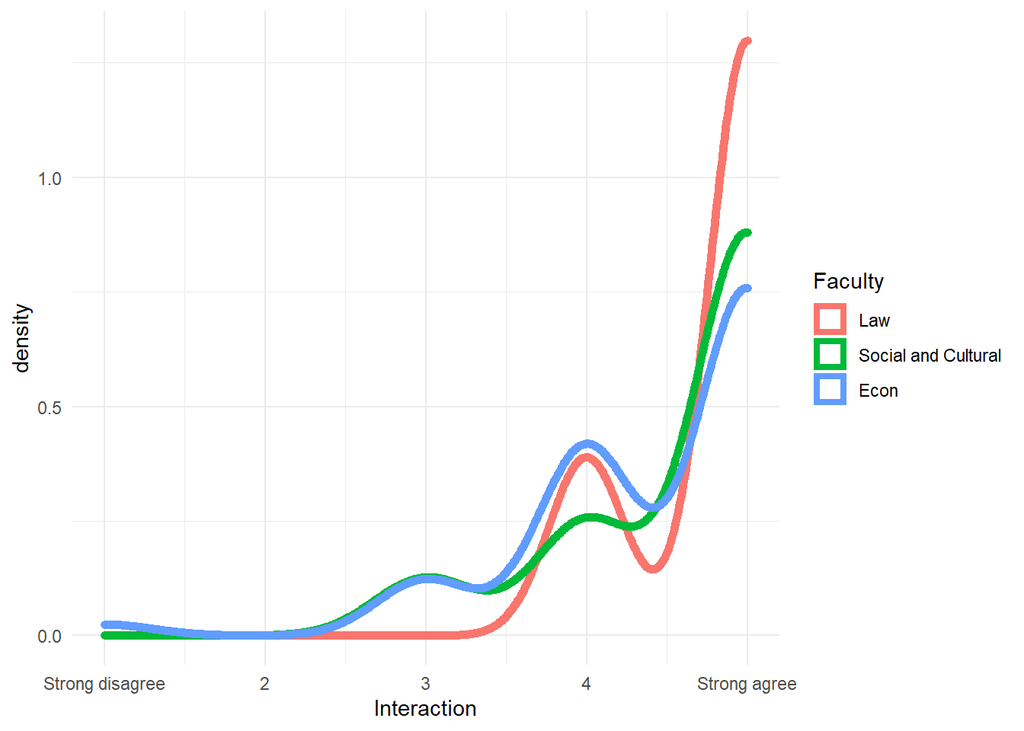

## Digital Content

**“I have the ability to develop digital content.”**

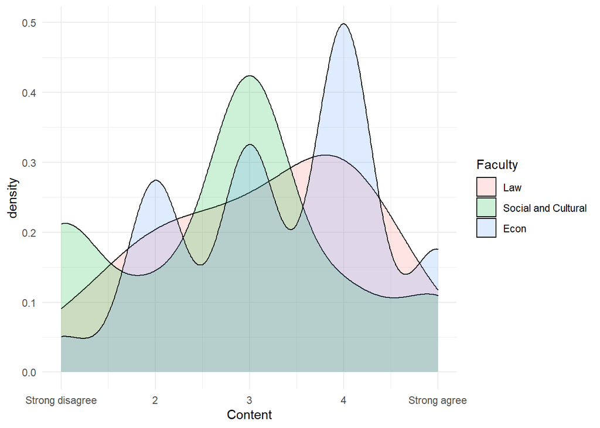

## Privacy and Data Protection

**“I have knowledge of data protection and privacy.”**

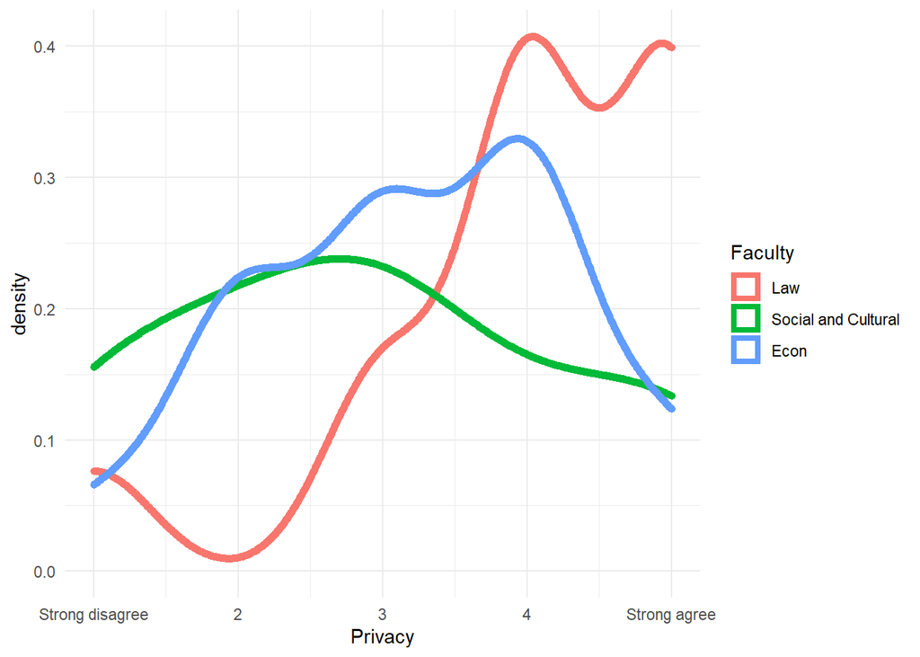

## Technical Problems

**“I solve technical problems.”**

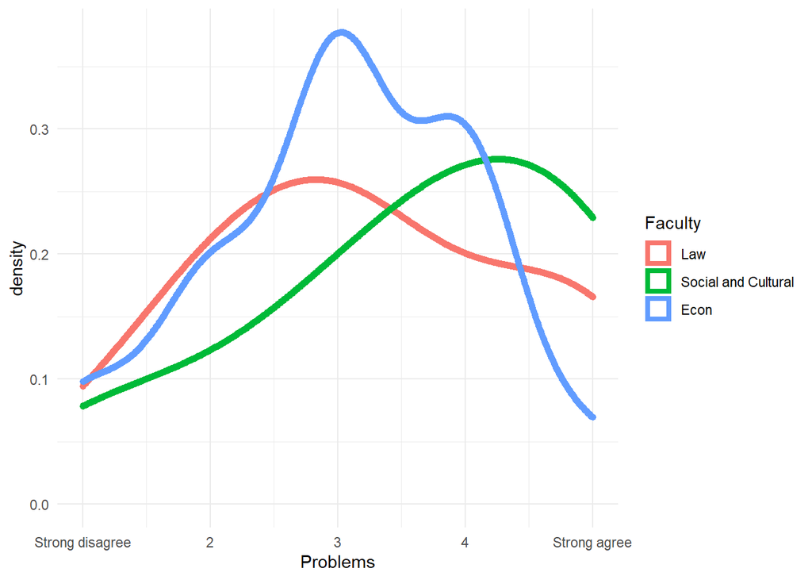

# Text Analysis

## Inspection (1 pt)

The open question “What digital skills do students at the Viadrina need?” has been answered by 45 students in some way. All German replies were translated into English using Deepl (in a programmatic way). Please use the `head()` function on `Skills_EN` in the `digital` data. Note that non-response is coded as `""` instead of `NA`.

```
## [1] "Excel"
## [2] "Besides the basic computer skills, some basic knowledge of Microsoft and Google services (MS Office, Google drive etc.). Furthermore, there are no high digital requirements at Viadrina."
## [3] ""
## [4] "Quite a lot, I feel that my fellow students have no idea how to properly use digital media and also programs like Office"
## [5] ""
## [6] "Digital research, Data visualisation / Content creation, Digital security and Legal literacy in the respective area"
```

## Text Cleaning (1 pt)

Load the `tidytext` package. Please define the following function `clean_text()` and apply it to `digital$Skills_EN`, store the result as `digital$Skills_EN_clean`. Check the details for your interest. It removes digits, punctuation, whitespaces and sets everything to lower case.

```r
library(tidytext)

# text cleaning
clean_text <- function(x) {
  x %>%
    # Remove digits
    str_remove_all("[:digit:]") %>%
    # Remove punctuation
    str_remove_all("[[:punct:]]") %>%
    # Make everything lowercase
    str_to_lower() %>%
    # Remove any trailing whitespace around the text
    str_trim("both")
}
```

```
## [1] "excel"
## [2] "besides the basic computer skills some basic knowledge of microsoft and google services ms office google drive etc furthermore there are no high digital requirements at viadrina"
## [3] ""
## [4] "quite a lot i feel that my fellow students have no idea how to properly use digital media and also programs like office"
## [5] ""
## [6] "digital research data visualisation  content creation digital security and legal literacy in the respective area"
```

## Tidytext Format (1 pt)

Pipe `digital` into the `unnest_tokens(word, Skills_EN_clean)` function. Pipe this into `count(word, sort=TRUE)`. Store the result as `tidytext`. Please show the result via `head(tidytext)`.

```
##      word  n
## 1      to 24
## 2     the 20
## 3     and 19
## 4      of 17
## 5 digital 11
## 6     use 11
```

## Stopwords (1 pt)

Please remove stopwords like *to* and *the*. Load a list of stopwords via `data(stop_words)`. Open the `stop_words` tibble for your interest and see what’s in there. Please pipe `tidytext` data to the anti join command `anti_join(stop_words)` and overwrite the `tidytext` object. Print `head(tidytext)` again.

```
##          word  n
## 1     digital 11
## 2       excel  7
## 3   knowledge  6
## 4     ability  5
## 5 information  5
## 6   microsoft  5
```

## Wordcloud (1 pt)

Use the package `wordcloud` to illustrate term frequency after text cleaning. Use the following code structure, complete the code and produce the following result. Try to change options for your own interest.

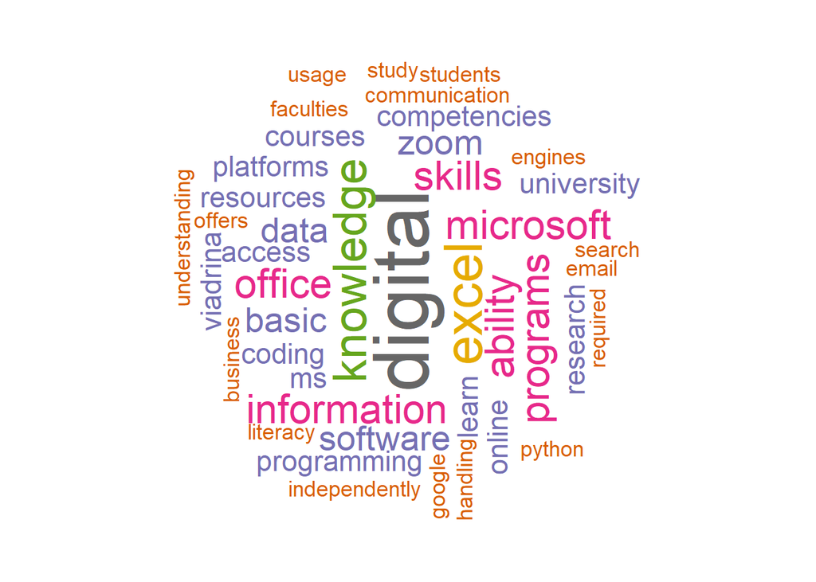

```r
library(wordcloud)

wordcloud(words = XXX, freq = XXX, min.freq = 2, max.words=200,
          random.order=FALSE, rot.per=0.35, colors=brewer.pal(8, "Dark2"))
```